# Project: Investigate a Dataset (TMBD- Movies Data Set!)

A.J. Lozano 1/7/2019

- Introduction
- Data Wrangling
- Exploratory Data Analysis
- Conclusions

## Introduction

> The TMDB Movie Data Set contains over 10,000 rows of information. The data touches on topics such as movie titles, release dates, revenue, and budgets.

#### We will use the data to answer Questions:

```
1) What movies generated the most profit?
2) What are runtime characteristics of the movies within the dataset?
3) What Directors have made the most movies, earn the most, and make the most on average per film?
```

```python
import pandas as pd
import numpy as np
import matplotlib as plt
import seaborn as sb
% matplotlib inline

df= pd.read_csv('tmdb-movies.csv')
```

## Data Wrangling

> In this section of the report, data is loaded, checked for cleanliness, and then trimmed and cleaned for analysis.

```python
df.info()

print('\n')

df.shape
```

```
<class 'pandas.core.frame.DataFrame'>
RangeIndex: 10866 entries, 0 to 10865
Data columns (total 21 columns):
id                      10866 non-null int64
imdb_id                 10856 non-null object
popularity              10866 non-null float64
budget                  10866 non-null int64
revenue                 10866 non-null int64
original_title          10866 non-null object
cast                    10790 non-null object
homepage                2936 non-null object
director                10822 non-null object
tagline                 8042 non-null object
keywords                9373 non-null object
overview                10862 non-null object
runtime                 10866 non-null int64
genres                  10843 non-null object
production_companies    9836 non-null object
release_date            10866 non-null object
vote_count              10866 non-null int64
vote_average            10866 non-null float64
release_year            10866 non-null int64
budget_adj              10866 non-null float64
revenue_adj             10866 non-null float64
dtypes: float64(4), int64(6), object(11)
memory usage: 1.7+ MB
```

```
(10866, 21)
```

### the database has a total of 21 columns with 10,866 entries(rows)

```python
df.head(1)
```

|  | id | imdb_id | popularity | budget | revenue | original_title | cast | homepage | director | tagline | ... | overview | runtime | genres | production_companies | release_date | vote_count | vote_average | release_year | budget_adj | revenue_adj |
| --- | --- | --- | --- | --- | --- | --- | --- | --- | --- | --- | --- | --- | --- | --- | --- | --- | --- | --- | --- | --- | --- |
| 0 | 135397 | tt0369610 | 32.985763 | 150000000 | 1513528810 | Jurassic World | Chris Pratt\|Bryce Dallas Howard\|Irrfan Khan\|Vi... | http://www.jurassicworld.com/ | Colin Trevorrow | The park is open. | ... | Twenty-two years after the events of Jurassic ... | 124 | Action\|Adventure\|Science Fiction\|Thriller | Universal Studios\|Amblin Entertainment\|Legenda... | 6/9/15 | 5562 | 6.5 | 2015 | 1.379999e+08 | 1.392446e+09 |

1 rows × 21 columns

```python
df.describe()
```

|  | id | popularity | budget | revenue | runtime | vote_count | vote_average | release_year | budget_adj | revenue_adj |
| --- | --- | --- | --- | --- | --- | --- | --- | --- | --- | --- |
| count | 10866.000000 | 10866.000000 | 1.086600e+04 | 1.086600e+04 | 10866.000000 | 10866.000000 | 10866.000000 | 10866.000000 | 1.086600e+04 | 1.086600e+04 |
| mean | 66064.177434 | 0.646441 | 1.462570e+07 | 3.982332e+07 | 102.070863 | 217.389748 | 5.974922 | 2001.322658 | 1.755104e+07 | 5.136436e+07 |
| std | 92130.136561 | 1.000185 | 3.091321e+07 | 1.170035e+08 | 31.381405 | 575.619058 | 0.935142 | 12.812941 | 3.430616e+07 | 1.446325e+08 |
| min | 5.000000 | 0.000065 | 0.000000e+00 | 0.000000e+00 | 0.000000 | 10.000000 | 1.500000 | 1960.000000 | 0.000000e+00 | 0.000000e+00 |
| 25% | 10596.250000 | 0.207583 | 0.000000e+00 | 0.000000e+00 | 90.000000 | 17.000000 | 5.400000 | 1995.000000 | 0.000000e+00 | 0.000000e+00 |
| 50% | 20669.000000 | 0.383856 | 0.000000e+00 | 0.000000e+00 | 99.000000 | 38.000000 | 6.000000 | 2006.000000 | 0.000000e+00 | 0.000000e+00 |
| 75% | 75610.000000 | 0.713817 | 1.500000e+07 | 2.400000e+07 | 111.000000 | 145.750000 | 6.600000 | 2011.000000 | 2.085325e+07 | 3.369710e+07 |
| max | 417859.000000 | 32.985763 | 4.250000e+08 | 2.781506e+09 | 900.000000 | 9767.000000 | 9.200000 | 2015.000000 | 4.250000e+08 | 2.827124e+09 |

```python
sum(df.duplicated())
```

[output not shown]

### I don't believe that homepage, popularity, tagline, keywords, vote count, overview,vote average, or imdb id are necessary for exploratory analysis

### imdb_id, cast, homepage, director, tagline, keywords, overview, genres, production companies all have missing values.

### some of the missing values are significant, others have a few missing values

### it looks like there is one row that is a duplicate and should be removed.

```python
#dropping columns
df.drop(['homepage', 'popularity', 'tagline', 'keywords', 'vote_count', 'vote_average', 'imdb_id', 'id', 'overview'], axis = 1, inplace = True)
```

```python
# dropping duplicate data
df.drop_duplicates(inplace = True)

sum(df.duplicated())
# all duplicates are now removed
```

[output not shown]

```python
df.info()
```

```
<class 'pandas.core.frame.DataFrame'>
Int64Index: 10865 entries, 0 to 10865
Data columns (total 12 columns):
budget                  10865 non-null int64
revenue                 10865 non-null int64
original_title          10865 non-null object
cast                    10789 non-null object
director                10821 non-null object
runtime                 10865 non-null int64
genres                  10842 non-null object
production_companies    9835 non-null object
release_date            10865 non-null object
release_year            10865 non-null int64
budget_adj              10865 non-null float64
revenue_adj             10865 non-null float64
dtypes: float64(2), int64(4), object(6)
memory usage: 1.1+ MB
```

### 9 out of the original 21 columns have been removed...leaving us with 12 columns.

```python
print(df['director'].describe())

print('\n The number of missing values in director column:', df['director'].isnull().sum())
print('---------------------')
```

```
count           10821
unique           5067
top       Woody Allen
freq               45
Name: director, dtype: object

 The number of missing values in director column: 44
---------------------
```

### director has missing values, but I would not classify as extensive.

### production company has missing values

### cast has missing values

```python
# removing the additional null rows from data set
df.dropna(inplace = True)
```

```python
# verified all null values removed.
df.isnull().sum()
```

```
budget                  0
revenue                 0
original_title          0
cast                    0
director                0
runtime                 0
genres                  0
production_companies    0
release_date            0
release_year            0
budget_adj              0
revenue_adj             0
dtype: int64
```

```python
# runtime details
df['runtime'].describe()

df['runtime'] = df['runtime'].replace(0, np.NaN)
```

### we can't have a movie with a 0 run time, after all...how could anyone watch a zero run movie?

#### we should replace 0 with NaN

```python
df.dtypes
```

```
budget                    int64
revenue                   int64
original_title           object
cast                     object
director                 object
runtime                 float64
genres                   object
production_companies     object
release_date             object
release_year              int64
budget_adj              float64
revenue_adj             float64
dtype: object
```

```python
# change adjusted_rev and adjusted_budget from float to int

format_change = ['budget_adj', 'revenue_adj']

df[format_change] = df[format_change].applymap(np.int64)
```

```python
# rename original_title to title
df.rename(columns = {'original_title' : 'title'}, inplace = True)
```

```python
# converting release year to whole year(number)
df["release_year"].round().astype(int);
```

```python
df.dtypes
```

```
budget                    int64
revenue                   int64
title                    object
cast                     object
director                 object
runtime                 float64
genres                   object
production_companies     object
release_date             object
release_year              int64
budget_adj                int64
revenue_adj               int64
dtype: object
```

```python
#converting release date to proper format

df.release_date = pd.to_datetime(df['release_date'])
```

```python
#verifying datetime change

df.head(1)
```

|  | budget | revenue | title | cast | director | runtime | genres | production_companies | release_date | release_year | budget_adj | revenue_adj |
| --- | --- | --- | --- | --- | --- | --- | --- | --- | --- | --- | --- | --- |
| 0 | 150000000 | 1513528810 | Jurassic World | Chris Pratt\|Bryce Dallas Howard\|Irrfan Khan\|Vi... | Colin Trevorrow | 124.0 | Action\|Adventure\|Science Fiction\|Thriller | Universal Studios\|Amblin Entertainment\|Legenda... | 2015-06-09 | 2015 | 137999939 | 1392445892 |

### The following functions will be used in our exploratory analysis

```python
def dir_film_avg(column1, column2, column3):
    return(groupby_sum(column1, column2) / val_counts(column3))

# returns the average revenue per film int / obj
```

```python
#min and max functions
    #taking the index value of the highest and lowest nnumber for searched column

def min(column_name):

    min_id = df[column_name].idxmin()
    min_stats = pd.DataFrame(df.loc[min_id])

    return min_stats
```

```python
def max(column_name):


    max_id = df[column_name].idxmax()
    #calling by index number,storing that row info to a variable
    max_stats = pd.DataFrame(df.loc[max_id])

    return max_stats
```

```python
#used for finding value counts of column variables
def val_counts(column_name):

    frequency = df[column_name].value_counts()


    return frequency
```

```python
def average(column_name):

    avg= df[column_name].mean()

    return avg
```

```python
def sum(column_name):

    sum = df[column_name].sum()

    return sum
```

```python
def groupby_sum(column_name1, column_name2):

    grp_sum = df.groupby(column_name1)[column_name2].sum()

    return grp_sum
```

```python
def groupby_mean(column_name1, column_name2):

    grp_mean = df.groupby(column_name1)[column_name2].mean()

    return grp_mean
```

```python
def groupby_three(column_name1, column_name2, column_name3):

    grp_three = df.groupby(column_name1)[column_name2,column_name3]
    #.sum(), .mean()
    return grp_three
```

```python
def groupby(column_name1, column_name2):

    grp = df.groupby(column_name1)[column_name2]

    return grp
```

```python
# cell used to confirm functions work. ....
#groupby('release_year','genres').value_counts()
#groupby_sum('production_companies', 'profit_adj').sort_values(ascending = False)
    #this function called revenues per production companies
```

## Exploratory Data Analysis

### Research Question 1: What movies generated the most and least profit?

```
                     a.) What movie made the most and least profit when adjusted for inflation?

                     b.) What do adjusted profits for movies look like year over year?

                     c.) What do the number of films released year over year look like?
```

```python
# create new profit column and calculate profit as adjusted rev - adjusted budget

df['profit_adj'] = df['revenue_adj'] - df['budget_adj']
```

```python
#confirm new profit column and calculation
df.head(1)
```

|  | budget | revenue | title | cast | director | runtime | genres | production_companies | release_date | release_year | budget_adj | revenue_adj | profit_adj |
| --- | --- | --- | --- | --- | --- | --- | --- | --- | --- | --- | --- | --- | --- |
| 0 | 150000000 | 1513528810 | Jurassic World | Chris Pratt\|Bryce Dallas Howard\|Irrfan Khan\|Vi... | Colin Trevorrow | 124.0 | Action\|Adventure\|Science Fiction\|Thriller | Universal Studios\|Amblin Entertainment\|Legenda... | 2015-06-09 | 2015 | 137999939 | 1392445892 | 1254445953 |

### We created the profits adjusted column to take inflation and real money values into account. It's a way to make sure that revenues are compared evenly throughout the years.

```python
#lets find out which movies made the most and least profit adjusted for inflation
max('profit_adj')
```

|  | 1329 |
| --- | --- |
| budget | 11000000 |
| revenue | 775398007 |
| title | Star Wars |
| cast | Mark Hamill\|Harrison Ford\|Carrie Fisher\|Peter ... |
| director | George Lucas |
| runtime | 121 |
| genres | Adventure\|Action\|Science Fiction |
| production_companies | Lucasfilm\|Twentieth Century Fox Film Corporation |
| release_date | 1977-03-20 00:00:00 |
| release_year | 1977 |
| budget_adj | 39575591 |
| revenue_adj | 2789712242 |
| profit_adj | 2750136651 |

```python
min('profit_adj')
```

|  | 2244 |
| --- | --- |
| budget | 425000000 |
| revenue | 11087569 |
| title | The Warrior's Way |
| cast | Kate Bosworth\|Jang Dong-gun\|Geoffrey Rush\|Dann... |
| director | Sngmoo Lee |
| runtime | 100 |
| genres | Adventure\|Fantasy\|Action\|Western\|Thriller |
| production_companies | Boram Entertainment Inc. |
| release_date | 2010-12-02 00:00:00 |
| release_year | 2010 |
| budget_adj | 425000000 |
| revenue_adj | 11087569 |
| profit_adj | -413912431 |

### Looks like star wars is the most profitable movie and The Warriors Way is the least profitable movie(both adjusted for inflation).

### I can't say I'm suprised, everyone knows Star Wars, but I've never heard of The Warriors Way.

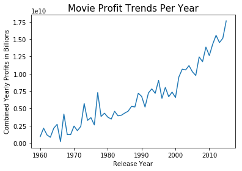

```python
# profits over the years
import matplotlib.pyplot as plt

movie_profits = groupby_sum('release_year', 'profit_adj')

plt.plot(movie_profits)
plt.xlabel('Release Year')
plt.ylabel('Combined Yearly Profits in Billions')

plt.title('Movie Profit Trends Per Year', fontsize = 15);
```

### Looks like 2015 had the highest combined profits when adjusted for inflation.

### Profits have continued on an upward trend since 1960.

### The y label values are multiplied by 1e10.

[output not shown]

```python
movie_profits.idxmax()
```

```
2015
```

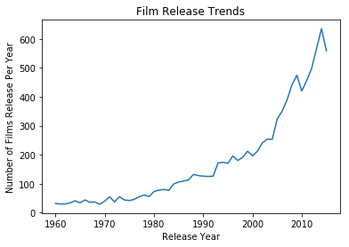

```python
# Films releases over the years

film_release = groupby('release_year', 'title').count()

plt.plot(film_release)
plt.xlabel('Release Year')
plt.ylabel('Number of Films Release Per Year')
plt.title('Film Release Trends');
```

```python
film_release.idxmax()
```

```
2014
```

### The above line graph depicts the number of movies released each year continuing in an upward trend.

### I would imagine that the reason for the upward trend in profits would be related to the increase in movie choices per year.

### 2014 was the year with the most releases in the dataset.

### Research Question 2: What are the Min and Max runtime characteristics for movies?

```
2b) What movies are the longest?

2c) How have runtimes changed year over year?

2d) What bins do runtimes fall into?
```

```python
max('runtime')
```

|  | 4041 |
| --- | --- |
| budget | 0 |
| revenue | 0 |
| title | Taken |
| cast | Dakota Fanning\|Matt Frewer\|Eric Close\|Emily Be... |
| director | Breck Eisner\|Félix Enríquez Alcalá\|John Faw... |
| runtime | 877 |
| genres | Science Fiction |
| production_companies | DreamWorks |
| release_date | 2002-12-02 00:00:00 |
| release_year | 2002 |
| budget_adj | 0 |
| revenue_adj | 0 |
| profit_adj | 0 |

### I'm not sure that is accurate, I've seen the movie and don't remember it going that long. We should probably change the figure to its 94 minute runtime.